# R: Full-Information Item Bi-factor and Two-Tier Analysis

| bfactor {mirt} | R Documentation |
| --- | --- |

## Full-Information Item Bi-factor and Two-Tier Analysis

### Description

`bfactor` fits a confirmatory maximum likelihood two-tier/bifactor/testlet model to dichotomous and polytomous data under the item response theory paradigm. The IRT models are fit using a dimensional reduction EM algorithm so that regardless of the number of specific factors estimated the model only uses the number of factors in the second-tier structure plus 1. For the bifactor model the maximum number of dimensions is only 2 since the second-tier only consists of a ubiquitous unidimensional factor. See `mirt` for appropriate methods to be used on the objects returned from the estimation.

### Usage

```r
bfactor(
  data,
  model,
  model2 = paste0("G = 1-", ncol(data)),
  group = NULL,
  quadpts = NULL,
  invariance = "",
  ...
)
```

### Arguments

[output not shown]

### Details

`bfactor` follows the item factor analysis strategy explicated by Gibbons and Hedeker (1992), Gibbons et al. (2007), and Cai (2010). Nested models may be compared via an approximate chi-squared difference test or by a reduction in AIC or BIC (accessible via `anova`). See `mirt` for more details regarding the IRT estimation approach used in this package.

The two-tier model has a specific block diagonal covariance structure between the primary and secondary latent traits. Namely, the secondary latent traits are assumed to be orthogonal to all traits and have a fixed variance of 1, while the primary traits can be organized to vary and covary with other primary traits in the model.

`\Sigma_{two-tier} = \left(\begin{array}{cc} G & 0 \\ 0 & diag(S) \end{array} \right)`

The bifactor model is a special case of the two-tier model when `G` above is a 1x1 matrix, and therefore only 1 primary factor is being modeled. Evaluation of the numerical integrals for the two-tier model requires only `ncol(G) + 1` dimensions for integration since the `S` second order (or 'specific') factors require only 1 integration grid due to the dimension reduction technique.

Note: for multiple group two-tier analyses only the second-tier means and variances should be freed since the specific factors are not treated independently due to the dimension reduction technique.

### Value

function returns an object of class `SingleGroupClass` (SingleGroupClass-class) or `MultipleGroupClass`(MultipleGroupClass-class).

### Author(s)

Phil Chalmers rphilip.chalmers@gmail.com

### References

Cai, L. (2010). A two-tier full-information item factor analysis model with applications. *Psychometrika, 75*, 581-612.

Chalmers, R., P. (2012). mirt: A Multidimensional Item Response Theory Package for the R Environment. *Journal of Statistical Software, 48*(6), 1-29. [doi:10.18637/jss.v048.i06](https://doi.org/10.18637/jss.v048.i06)

Bradlow, E.T., Wainer, H., & Wang, X. (1999). A Bayesian random effects model for testlets. *Psychometrika, 64*, 153-168.

Gibbons, R. D., & Hedeker, D. R. (1992). Full-information Item Bi-Factor Analysis. *Psychometrika, 57*, 423-436.

Gibbons, R. D., Darrell, R. B., Hedeker, D., Weiss, D. J., Segawa, E., Bhaumik, D. K., Kupfer, D. J., Frank, E., Grochocinski, V. J., & Stover, A. (2007). Full-Information item bifactor analysis of graded response data. *Applied Psychological Measurement, 31*, 4-19.

Wainer, H., Bradlow, E.T., & Wang, X. (2007). Testlet response theory and its applications. New York, NY: Cambridge University Press.

### See Also

`mirt`

### Examples

```r
## No test:

### load SAT12 and compute bifactor model with 3 specific factors
data(SAT12)
data <- key2binary(SAT12,
  key = c(1,4,5,2,3,1,2,1,3,1,2,4,2,1,5,3,4,4,1,4,3,3,4,1,3,5,1,3,1,5,4,5))
specific <- c(2,3,2,3,3,2,1,2,1,1,1,3,1,3,1,2,1,1,3,3,1,1,3,1,3,3,1,3,2,3,1,2)
mod1 <- bfactor(data, specific)
summary(mod1)
```

```
##              G      S1      S2      S3      h2
## Item.1  0.4078  0.0000  0.2273  0.0000 0.21799
## Item.2  0.6195  0.0000  0.0000  0.3391 0.49881
## Item.3  0.5573  0.0000 -0.0744  0.0000 0.31612
## Item.4  0.2808  0.0000  0.0000  0.3101 0.17503
## Item.5  0.4779  0.0000  0.0000  0.2544 0.29311
## Item.6  0.5341  0.0000  0.2724  0.0000 0.35948
## Item.7  0.4741  0.4210  0.0000  0.0000 0.40199
## Item.8  0.3537  0.0000  0.2732  0.0000 0.19971
## Item.9  0.2181  0.5321  0.0000  0.0000 0.33068
## Item.10 0.4849  0.3792  0.0000  0.0000 0.37895
## Item.11 0.6442  0.3321  0.0000  0.0000 0.52536
## Item.12 0.0699  0.0000  0.0000  0.1592 0.03023
## Item.13 0.5219  0.2743  0.0000  0.0000 0.34764
## Item.14 0.4791  0.0000  0.0000  0.4563 0.43776
## Item.15 0.5985  0.2402  0.0000  0.0000 0.41590
## Item.16 0.3885  0.0000  0.2049  0.0000 0.19292
## Item.17 0.6636  0.1177  0.0000  0.0000 0.45423
## Item.18 0.7163  0.0775  0.0000  0.0000 0.51903
## Item.19 0.4520  0.0000  0.0000  0.0198 0.20466
## Item.20 0.6578  0.0000  0.0000  0.1792 0.46478
## Item.21 0.2806  0.3451  0.0000  0.0000 0.19787
## Item.22 0.7025 -0.0281  0.0000  0.0000 0.49425
## Item.23 0.3236  0.0000  0.0000  0.2657 0.17536
## Item.24 0.5848  0.1030  0.0000  0.0000 0.35266
## Item.25 0.3732  0.0000  0.0000  0.3297 0.24799
## Item.26 0.6430  0.0000  0.0000  0.2124 0.45854
## Item.27 0.7374  0.1554  0.0000  0.0000 0.56792
## Item.28 0.5256  0.0000  0.0000  0.0758 0.28199
## Item.29 0.4185  0.0000  0.7071  0.0000 0.67516
## Item.30 0.2455  0.0000  0.0000 -0.0959 0.06946
## Item.31 0.8333 -0.0872  0.0000  0.0000 0.70202
## Item.32 0.0780  0.0000  0.0165  0.0000 0.00635
##
## SS loadings:  8.435 1.03 0.748 0.781
## Proportion Var:  0.264 0.032 0.023 0.024
##
## Factor correlations:
##
##    G S1 S2 S3
## G  1
## S1 0  1
## S2 0  0  1
## S3 0  0  0  1
```

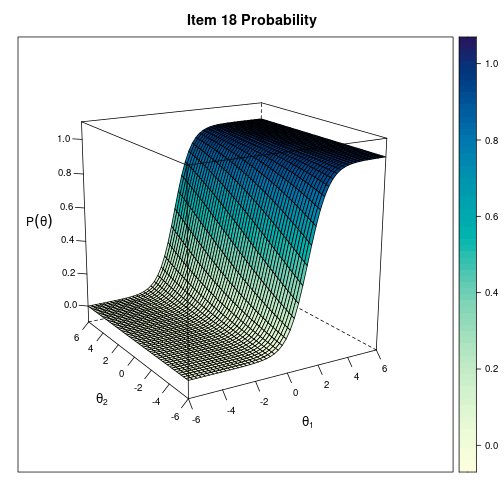

```r
itemplot(mod1, 18, drop.zeros = TRUE) #drop the zero slopes to allow plotting
```

```r
# alternative model definition via ?mirt.model syntax
specific2 <- "S1 = 7,9,10,11,13,15,17,18,21,22,24,27,31
              S2 = 1,3,6,8,16,29,32
              S3 = 2,4,5,12,14,19,20,23,25,26,28,30"
mod2 <- bfactor(data, specific2)
anova(mod1, mod2) # same
```

```
##          AIC    SABIC       HQ      BIC    logLik X2 df   p
## mod1 19062.1 19179.44 19226.42 19484.21 -9435.052
## mod2 19062.1 19179.44 19226.42 19484.21 -9435.052  0  0 NaN
```

```r
# also equivalent using item names instead (not run)
specific3 <- "S1 = Item.7, Item.9, Item.10, Item.11, Item.13, Item.15,
                Item.17, Item.18, Item.21, Item.22, Item.24, Item.27, Item.31
              S2 = Item.1, Item.3, Item.6, Item.8, Item.16, Item.29, Item.32
              S3 = Item.2, Item.4, Item.5, Item.12, Item.14, Item.19,
                Item.20, Item.23, Item.25, Item.26, Item.28, Item.30"
# mod3 <- bfactor(data, specific3)
# anova(mod1, mod2, mod3)  # all same

### Try with fixed guessing parameters added
guess <- rep(.1,32)
mod2 <- bfactor(data, specific, guess = guess)
coef(mod2)
```

```
## $Item.1
##        a1 a2    a3 a4      d   g u
## par 1.225  0 0.624  0 -1.822 0.1 1
##
## $Item.2
##        a1 a2 a3    a4     d   g u
## par 1.721  0  0 0.954 0.171 0.1 1
##
## $Item.3
##        a1 a2     a3 a4      d   g u
## par 2.415  0 -0.459  0 -2.602 0.1 1
##
## $Item.4
##        a1 a2 a3    a4      d   g u
## par 0.745  0  0 0.695 -0.989 0.1 1
##
## $Item.5
##        a1 a2 a3    a4     d   g u
## par 1.048  0  0 0.603 0.419 0.1 1
##
## $Item.6
##       a1 a2    a3 a4      d   g u
## par 3.06  0 0.501  0 -5.002 0.1 1
##
## $Item.7
##        a1    a2 a3 a4     d   g u
## par 1.121 0.839  0  0 1.373 0.1 1
##
## $Item.8
##        a1 a2    a3 a4      d   g u
## par 1.956  0 1.443  0 -3.772 0.1 1
##
## $Item.9
##        a1    a2 a3 a4     d   g u
## par 0.512 1.236  0  0 2.484 0.1 1
##
## $Item.10
##       a1    a2 a3 a4      d   g u
## par 1.68 1.506  0  0 -1.031 0.1 1
##
```

[output cut: 78 more lines]

```
## par 0.479  0  0 -0.128 -0.527 0.1 1
##
## $Item.31
##        a1    a2 a3 a4     d   g u
## par 3.173 -0.82  0  0 3.316 0.1 1
##
## $Item.32
##        a1 a2     a3 a4      d   g u
## par 0.534  0 -0.053  0 -2.786 0.1 1
##
## $GroupPars
##     MEAN_1 MEAN_2 MEAN_3 MEAN_4 COV_11 COV_21 COV_31 COV_41 COV_22 COV_32
## par      0      0      0      0      1      0      0      0      1      0
##     COV_42 COV_33 COV_43 COV_44
## par      0      1      0      1
```

```r
anova(mod1, mod2)
```

```
##           AIC    SABIC       HQ      BIC    logLik     X2 df   p
## mod1 19062.10 19179.44 19226.42 19484.21 -9435.052
## mod2 19009.55 19126.88 19173.87 19431.65 -9408.775 52.553  0 NaN
```

```r
## don't estimate specific factor for item 32
specific[32] <- NA
mod3 <- bfactor(data, specific)
anova(mod3, mod1)
```

```
##           AIC    SABIC       HQ      BIC    logLik   X2 df     p
## mod3 19060.12 19176.23 19222.73 19477.83 -9435.062
## mod1 19062.10 19179.44 19226.42 19484.21 -9435.052 0.02  1 0.886
```

```r
# same, but with syntax (not run)
specific3 <- "S1 = 7,9,10,11,13,15,17,18,21,22,24,27,31
              S2 = 1,3,6,8,16,29
              S3 = 2,4,5,12,14,19,20,23,25,26,28,30"
# mod3b <- bfactor(data, specific3)
# anova(mod3b)


#########
# mixed itemtype example

# simulate data
a <- matrix(c(
1,0.5,NA,
1,0.5,NA,
1,0.5,NA,
1,0.5,NA,
1,0.5,NA,
1,0.5,NA,
1,0.5,NA,
1,NA,0.5,
1,NA,0.5,
1,NA,0.5,
1,NA,0.5,
1,NA,0.5,
1,NA,0.5,
1,NA,0.5),ncol=3,byrow=TRUE)

d <- matrix(c(
-1.0,NA,NA,
-1.5,NA,NA,
 1.5,NA,NA,
 0.0,NA,NA,
2.5,1.0,-1,
3.0,2.0,-0.5,
3.0,2.0,-0.5,
3.0,2.0,-0.5,
2.5,1.0,-1,
2.0,0.0,NA,
-1.0,NA,NA,
-1.5,NA,NA,
 1.5,NA,NA,
 0.0,NA,NA),ncol=3,byrow=TRUE)
items <- rep('2PL', 14)
items[5:10] <- 'graded'

sigma <- diag(3)
dataset <- simdata(a,d,5000,itemtype=items,sigma=sigma)
itemstats(dataset)
```

```
## $overall
##     N mean_total.score sd_total.score ave.r  sd.r alpha SEM.alpha
##  5000           15.328          4.374 0.168 0.032 0.723     2.301
##
## $itemstats
##            N  mean    sd total.r total.r_if_rm alpha_if_rm
## Item_1  5000 0.299 0.458   0.411         0.319       0.711
## Item_2  5000 0.238 0.426   0.415         0.330       0.711
## Item_3  5000 0.777 0.416   0.399         0.315       0.712
## Item_4  5000 0.501 0.500   0.448         0.349       0.708
## Item_5  5000 1.904 0.967   0.572         0.393       0.703
## Item_6  5000 2.185 0.871   0.535         0.370       0.705
## Item_7  5000 2.183 0.864   0.535         0.371       0.704
## Item_8  5000 2.169 0.860   0.544         0.382       0.703
## Item_9  5000 1.911 0.964   0.573         0.395       0.702
## Item_10 5000 1.343 0.740   0.508         0.366       0.704
## Item_11 5000 0.314 0.464   0.417         0.323       0.711
## Item_12 5000 0.223 0.416   0.384         0.298       0.714
## Item_13 5000 0.777 0.416   0.380         0.294       0.714
## Item_14 5000 0.504 0.500   0.460         0.363       0.707
##
## $proportions
##             0     1     2     3
## Item_1  0.701 0.299    NA    NA
## Item_2  0.762 0.238    NA    NA
## Item_3  0.223 0.777    NA    NA
## Item_4  0.499 0.501    NA    NA
## Item_5  0.112 0.185 0.391 0.312
## Item_6  0.072 0.088 0.423 0.417
## Item_7  0.071 0.086 0.432 0.411
## Item_8  0.072 0.083 0.448 0.397
## Item_9  0.106 0.195 0.381 0.318
## Item_10 0.161 0.335 0.504    NA
## Item_11 0.686 0.314    NA    NA
## Item_12 0.777 0.223    NA    NA
## Item_13 0.223 0.777    NA    NA
## Item_14 0.496 0.504    NA    NA
```

```r
specific <- "S1 = 1-7
             S2 = 8-14"
simmod <- bfactor(dataset, specific)
coef(simmod, simplify=TRUE)
```

```
## $items
##            a1    a2    a3      d  g  u    d1    d2     d3
## Item_1  0.930 0.490 0.000 -1.039  0  1    NA    NA     NA
## Item_2  1.121 0.406 0.000 -1.470  0  1    NA    NA     NA
## Item_3  0.975 0.618 0.000  1.560  0  1    NA    NA     NA
## Item_4  0.950 0.456 0.000  0.006  0  1    NA    NA     NA
## Item_5  0.968 0.619 0.000     NA NA NA 2.528 1.083 -0.992
## Item_6  0.945 0.432 0.000     NA NA NA 2.987 1.985 -0.411
## Item_7  0.974 0.540 0.000     NA NA NA 3.068 2.055 -0.450
## Item_8  0.997 0.000 0.531     NA NA NA 3.054 2.071 -0.531
## Item_9  1.001 0.000 0.490     NA NA NA 2.573 1.057 -0.943
## Item_10 0.931 0.000 0.525     NA NA NA 1.993 0.021     NA
## Item_11 0.946 0.000 0.519 -0.961  0  1    NA    NA     NA
## Item_12 0.957 0.000 0.593 -1.549  0  1    NA    NA     NA
## Item_13 0.882 0.000 0.543  1.504  0  1    NA    NA     NA
## Item_14 1.022 0.000 0.462  0.023  0  1    NA    NA     NA
##
## $means
##  G S1 S2
##  0  0  0
##
## $cov
##    G S1 S2
## G  1  0  0
## S1 0  1  0
## S2 0  0  1
```

```r
#########
# General testlet response model (Wainer, 2007)

# simulate data
set.seed(1234)
a <- matrix(0, 12, 4)
a[,1] <- rlnorm(12, .2, .3)
ind <- 1
for(i in 1:3){
   a[ind:(ind+3),i+1] <- a[ind:(ind+3),1]
   ind <- ind+4
}
print(a)
```

```
##            [,1]      [,2]     [,3]      [,4]
##  [1,] 0.8503394 0.8503394 0.000000 0.0000000
##  [2,] 1.3274088 1.3274088 0.000000 0.0000000
##  [3,] 1.6910208 1.6910208 0.000000 0.0000000
##  [4,] 0.6042850 0.6042850 0.000000 0.0000000
##  [5,] 1.3892130 0.0000000 1.389213 0.0000000
##  [6,] 1.4216480 0.0000000 1.421648 0.0000000
##  [7,] 1.0279618 0.0000000 1.027962 0.0000000
##  [8,] 1.0366667 0.0000000 1.036667 0.0000000
##  [9,] 1.0311394 0.0000000 0.000000 1.0311394
## [10,] 0.9351846 0.0000000 0.000000 0.9351846
## [11,] 1.0584888 0.0000000 0.000000 1.0584888
## [12,] 0.9052755 0.0000000 0.000000 0.9052755
```

```r
d <- rnorm(12, 0, .5)
sigma <- diag(c(1, .5, 1, .5))
dataset <- simdata(a,d,2000,itemtype=rep('2PL', 12),sigma=sigma)
itemstats(dataset)
```

```
## $overall
##     N mean_total.score sd_total.score ave.r  sd.r alpha SEM.alpha
##  2000                6          2.929 0.175 0.068 0.717     1.558
##
## $itemstats
##            N  mean    sd total.r total.r_if_rm alpha_if_rm
## Item_1  2000 0.426 0.495   0.438         0.287       0.708
## Item_2  2000 0.502 0.500   0.560         0.425       0.689
## Item_3  2000 0.571 0.495   0.575         0.445       0.686
## Item_4  2000 0.502 0.500   0.383         0.224       0.716
## Item_5  2000 0.464 0.499   0.549         0.413       0.690
## Item_6  2000 0.436 0.496   0.561         0.428       0.688
## Item_7  2000 0.440 0.497   0.500         0.356       0.698
## Item_8  2000 0.693 0.462   0.474         0.339       0.701
## Item_9  2000 0.511 0.500   0.481         0.334       0.701
## Item_10 2000 0.456 0.498   0.465         0.316       0.704
## Item_11 2000 0.458 0.498   0.459         0.309       0.705
## Item_12 2000 0.540 0.498   0.475         0.327       0.702
##
## $proportions
##             0     1
## Item_1  0.575 0.426
## Item_2  0.498 0.502
## Item_3  0.430 0.571
## Item_4  0.498 0.502
## Item_5  0.536 0.464
## Item_6  0.564 0.436
## Item_7  0.559 0.440
## Item_8  0.308 0.693
## Item_9  0.488 0.511
## Item_10 0.543 0.456
## Item_11 0.541 0.458
## Item_12 0.460 0.540
```

```r
# estimate by applying constraints and freeing the latent variances
specific <- "S1 = 1-4
             S2 = 5-8
             S3 = 9-12"
model <- "G = 1-12
          CONSTRAIN = (1, a1, a2), (2, a1, a2), (3, a1, a2), (4, a1, a2),
            (5, a1, a3), (6, a1, a3), (7, a1, a3), (8, a1, a3),
            (9, a1, a4), (10, a1, a4), (11, a1, a4), (12, a1, a4)
          COV = S1*S1, S2*S2, S3*S3"

simmod <- bfactor(dataset, specific, model)
coef(simmod, simplify=TRUE)
```

```
## $items
##            a1    a2    a3    a4      d g u
## Item_1  0.794 0.794 0.000 0.000 -0.359 0 1
## Item_2  1.544 1.544 0.000 0.000  0.011 0 1
## Item_3  1.762 1.762 0.000 0.000  0.479 0 1
## Item_4  0.544 0.544 0.000 0.000  0.011 0 1
## Item_5  1.386 0.000 1.386 0.000 -0.244 0 1
## Item_6  1.497 0.000 1.497 0.000 -0.449 0 1
## Item_7  0.853 0.000 0.853 0.000 -0.312 0 1
## Item_8  0.953 0.000 0.953 0.000  1.101 0 1
## Item_9  0.981 0.000 0.000 0.981  0.058 0 1
## Item_10 0.913 0.000 0.000 0.913 -0.217 0 1
## Item_11 0.868 0.000 0.000 0.868 -0.204 0 1
## Item_12 0.966 0.000 0.000 0.966  0.206 0 1
##
## $means
##  G S1 S2 S3
##  0  0  0  0
##
## $cov
##    G    S1    S2    S3
## G  1 0.000 0.000 0.000
## S1 0 0.452 0.000 0.000
## S2 0 0.000 1.135 0.000
## S3 0 0.000 0.000 0.432
```

```r
# Constrained testlet model (Bradlow, 1999)
model2 <- "G = 1-12
          CONSTRAIN = (1, a1, a2), (2, a1, a2), (3, a1, a2), (4, a1, a2),
            (5, a1, a3), (6, a1, a3), (7, a1, a3), (8, a1, a3),
            (9, a1, a4), (10, a1, a4), (11, a1, a4), (12, a1, a4),
            (GROUP, COV_22, COV_33, COV_44)
          COV = S1*S1, S2*S2, S3*S3"

simmod2 <- bfactor(dataset, specific, model2)
coef(simmod2, simplify=TRUE)
```

```
## $items
##            a1    a2    a3    a4      d g u
## Item_1  0.744 0.744 0.000 0.000 -0.360 0 1
## Item_2  1.453 1.453 0.000 0.000  0.010 0 1
## Item_3  1.664 1.664 0.000 0.000  0.482 0 1
## Item_4  0.509 0.509 0.000 0.000  0.011 0 1
## Item_5  1.541 0.000 1.541 0.000 -0.241 0 1
## Item_6  1.670 0.000 1.670 0.000 -0.445 0 1
## Item_7  0.968 0.000 0.968 0.000 -0.313 0 1
## Item_8  1.075 0.000 1.075 0.000  1.098 0 1
## Item_9  0.927 0.000 0.000 0.927  0.059 0 1
## Item_10 0.854 0.000 0.000 0.854 -0.218 0 1
## Item_11 0.813 0.000 0.000 0.813 -0.205 0 1
## Item_12 0.908 0.000 0.000 0.908  0.207 0 1
##
## $means
##  G S1 S2 S3
##  0  0  0  0
##
## $cov
##    G    S1    S2    S3
## G  1 0.000 0.000 0.000
## S1 0 0.667 0.000 0.000
## S2 0 0.000 0.667 0.000
## S3 0 0.000 0.000 0.667
```

```r
anova(simmod2, simmod)
```

```
##              AIC    SABIC       HQ      BIC   logLik     X2 df     p
## simmod2 30256.59 30317.19 30308.00 30396.61 -15103.3
## simmod  30248.79 30314.24 30304.32 30400.02 -15097.4 11.795  2 0.003
```

```r
#########
# Two-tier model

# simulate data
set.seed(1234)
a <- matrix(c(
  0,1,0.5,NA,NA,
  0,1,0.5,NA,NA,
  0,1,0.5,NA,NA,
  0,1,0.5,NA,NA,
  0,1,0.5,NA,NA,
  0,1,NA,0.5,NA,
  0,1,NA,0.5,NA,
  0,1,NA,0.5,NA,
  1,0,NA,0.5,NA,
  1,0,NA,0.5,NA,
  1,0,NA,0.5,NA,
  1,0,NA,NA,0.5,
  1,0,NA,NA,0.5,
  1,0,NA,NA,0.5,
  1,0,NA,NA,0.5,
  1,0,NA,NA,0.5),ncol=5,byrow=TRUE)

d <- matrix(rnorm(16))
items <- rep('2PL', 16)

sigma <- diag(5)
sigma[1,2] <- sigma[2,1] <- .4
dataset <- simdata(a,d,2000,itemtype=items,sigma=sigma)
itemstats(dataset)
```

```
## $overall
##     N mean_total.score sd_total.score ave.r  sd.r alpha SEM.alpha
##  2000            7.086          3.077 0.108 0.058 0.662      1.79
##
## $itemstats
##            N  mean    sd total.r total.r_if_rm alpha_if_rm
## Item_1  2000 0.288 0.453   0.378         0.241       0.650
## Item_2  2000 0.571 0.495   0.422         0.276       0.646
## Item_3  2000 0.705 0.456   0.381         0.245       0.650
## Item_4  2000 0.133 0.340   0.289         0.183       0.656
## Item_5  2000 0.601 0.490   0.393         0.246       0.650
## Item_6  2000 0.587 0.492   0.419         0.274       0.646
## Item_7  2000 0.379 0.485   0.444         0.304       0.642
## Item_8  2000 0.378 0.485   0.400         0.256       0.649
## Item_9  2000 0.386 0.487   0.392         0.246       0.650
## Item_10 2000 0.322 0.467   0.400         0.261       0.648
## Item_11 2000 0.402 0.490   0.455         0.315       0.640
## Item_12 2000 0.318 0.466   0.414         0.278       0.646
## Item_13 2000 0.368 0.482   0.423         0.281       0.645
## Item_14 2000 0.498 0.500   0.424         0.277       0.646
## Item_15 2000 0.669 0.471   0.394         0.254       0.649
## Item_16 2000 0.482 0.500   0.444         0.300       0.642
##
## $proportions
##             0     1
## Item_1  0.713 0.288
## Item_2  0.430 0.571
## Item_3  0.295 0.705
## Item_4  0.867 0.133
## Item_5  0.400 0.601
## Item_6  0.413 0.587
## Item_7  0.621 0.379
## Item_8  0.622 0.378
## Item_9  0.614 0.386
## Item_10 0.678 0.322
## Item_11 0.598 0.402
## Item_12 0.681 0.318
## Item_13 0.632 0.368
## Item_14 0.502 0.498
## Item_15 0.330 0.669
## Item_16 0.518 0.482
```

```r
specific <- "S1 = 1-5
             S2 = 6-11
             S3 = 12-16"
model <- '
    G1 = 1-8
    G2 = 9-16
    COV = G1*G2'

# quadpts dropped for faster estimation, but not as precise
simmod <- bfactor(dataset, specific, model, quadpts = 9, TOL = 1e-3)
coef(simmod, simplify=TRUE)
```

```
## $items
##            a1    a2    a3    a4    a5      d g u
## Item_1  0.965 0.000 0.385 0.000 0.000 -1.100 0 1
## Item_2  1.076 0.000 0.550 0.000 0.000  0.363 0 1
## Item_3  0.898 0.000 0.592 0.000 0.000  1.068 0 1
## Item_4  0.896 0.000 0.710 0.000 0.000 -2.293 0 1
## Item_5  0.892 0.000 0.848 0.000 0.000  0.526 0 1
## Item_6  1.013 0.000 0.000 0.413 0.000  0.435 0 1
## Item_7  1.162 0.000 0.000 0.451 0.000 -0.639 0 1
## Item_8  0.945 0.000 0.000 0.609 0.000 -0.623 0 1
## Item_9  0.000 0.831 0.000 0.371 0.000 -0.544 0 1
## Item_10 0.000 0.925 0.000 0.610 0.000 -0.926 0 1
## Item_11 0.000 1.142 0.000 0.495 0.000 -0.517 0 1
## Item_12 0.000 0.978 0.000 0.000 0.634 -0.964 0 1
## Item_13 0.000 1.108 0.000 0.000 0.437 -0.694 0 1
## Item_14 0.000 1.004 0.000 0.000 0.321 -0.012 0 1
## Item_15 0.000 0.916 0.000 0.000 0.758  0.897 0 1
## Item_16 0.000 1.020 0.000 0.000 0.650 -0.096 0 1
##
## $means
## G1 G2 S1 S2 S3
##  0  0  0  0  0
##
## $cov
##       G1    G2 S1 S2 S3
## G1 1.000 0.412  0  0  0
## G2 0.412 1.000  0  0  0
## S1 0.000 0.000  1  0  0
## S2 0.000 0.000  0  1  0
## S3 0.000 0.000  0  0  1
```

```r
summary(simmod)
```

```
##            G1    G2    S1    S2    S3    h2
## Item_1  0.484 0.000 0.193 0.000 0.000 0.271
## Item_2  0.516 0.000 0.263 0.000 0.000 0.335
## Item_3  0.446 0.000 0.294 0.000 0.000 0.285
## Item_4  0.437 0.000 0.346 0.000 0.000 0.311
## Item_5  0.425 0.000 0.404 0.000 0.000 0.343
## Item_6  0.501 0.000 0.000 0.204 0.000 0.293
## Item_7  0.551 0.000 0.000 0.214 0.000 0.349
## Item_8  0.463 0.000 0.000 0.299 0.000 0.304
## Item_9  0.000 0.431 0.000 0.192 0.000 0.222
## Item_10 0.000 0.456 0.000 0.300 0.000 0.298
## Item_11 0.000 0.541 0.000 0.235 0.000 0.348
## Item_12 0.000 0.474 0.000 0.000 0.307 0.319
## Item_13 0.000 0.533 0.000 0.000 0.210 0.329
## Item_14 0.000 0.501 0.000 0.000 0.160 0.277
## Item_15 0.000 0.441 0.000 0.000 0.365 0.328
## Item_16 0.000 0.488 0.000 0.000 0.311 0.336
##
## SS loadings:  1.839 1.88 0.476 0.359 0.395
## Proportion Var:  0.115 0.118 0.03 0.022 0.025
##
## Factor correlations:
##
##       G1 G2 S1 S2 S3
## G1 1.000
## G2 0.412  1
## S1 0.000  0  1
## S2 0.000  0  0  1
## S3 0.000  0  0  0  1
```

```r
itemfit(simmod, QMC=TRUE)
```

```
##       item   S_X2 df.S_X2 RMSEA.S_X2 p.S_X2
## 1   Item_1  7.103       9      0.000  0.626
## 2   Item_2 13.326      10      0.013  0.206
## 3   Item_3  8.332       9      0.000  0.501
## 4   Item_4  8.531      10      0.000  0.577
## 5   Item_5  7.170      10      0.000  0.709
## 6   Item_6  3.967      10      0.000  0.949
## 7   Item_7  8.350      10      0.000  0.595
## 8   Item_8 16.010      10      0.017  0.099
## 9   Item_9 17.529      10      0.019  0.063
## 10 Item_10 12.058      10      0.010  0.281
## 11 Item_11 13.567      10      0.013  0.194
## 12 Item_12 13.907       9      0.017  0.126
## 13 Item_13 11.144      10      0.008  0.346
## 14 Item_14  7.852      10      0.000  0.643
## 15 Item_15 14.142       9      0.017  0.117
## 16 Item_16  5.926      10      0.000  0.821
```

```r
M2(simmod, QMC=TRUE)
```

```
##             M2 df         p RMSEA RMSEA_5   RMSEA_95      SRMSR      TLI CFI
## stats 86.28163 87 0.5015988     0       0 0.01201603 0.01662365 1.000285   1
```

```r
residuals(simmod, QMC=TRUE)
```

```
## LD matrix (lower triangle) and standardized residual correlations (upper triangle)
##
## Upper triangle summary:
##    Min. 1st Qu.  Median    Mean 3rd Qu.    Max.
##  -0.046  -0.011  -0.002  -0.001   0.012   0.041
##
##         Item_1 Item_2 Item_3 Item_4 Item_5 Item_6 Item_7 Item_8 Item_9 Item_10
## Item_1         -0.011 -0.015 -0.007  0.016  0.003  0.006 -0.002  0.004  -0.009
## Item_2   0.263        -0.002  0.005 -0.001  0.016 -0.022  0.021 -0.003  -0.006
## Item_3   0.441  0.008         0.014 -0.001  0.029 -0.017 -0.011 -0.021  -0.028
## Item_4   0.086  0.054  0.376        -0.014 -0.023  0.021 -0.004  0.020  -0.040
## Item_5   0.514  0.004  0.003  0.386        -0.028  0.011  0.014 -0.021   0.013
## Item_6   0.015  0.483  1.630  1.038  1.588        -0.022 -0.009  0.031  -0.004
## Item_7   0.077  0.996  0.590  0.852  0.258  0.992        -0.007 -0.004   0.013
## Item_8   0.012  0.858  0.264  0.039  0.377  0.154  0.094        -0.020   0.008
## Item_9   0.033  0.017  0.863  0.803  0.890  1.974  0.037  0.808          0.001
## Item_10  0.157  0.084  1.528  3.158  0.360  0.038  0.330  0.128  0.001
## Item_11  0.510  0.125  2.195  0.231  0.004  0.215  1.049  0.004  0.031   0.754
## Item_12  2.017  0.253  1.865  0.388  0.005  0.417  0.074  0.090  0.443   0.042
## Item_13  0.470  2.122  0.125  0.271  0.881  0.264  0.310  4.304  0.009   0.059
## Item_14  0.101  1.546  0.165  0.006  0.296  0.004  1.672  0.765  3.341   0.066
## Item_15  0.822  0.257  0.011  0.442  0.443  0.113  0.526  0.297  2.306   0.044
## Item_16  0.097  0.627  1.486  0.127  0.445  0.011  0.732  0.061  0.007   0.944
##         Item_11 Item_12 Item_13 Item_14 Item_15 Item_16
## Item_1   -0.016  -0.032   0.015  -0.007   0.020  -0.007
## Item_2    0.008   0.011  -0.033  -0.028  -0.011   0.018
## Item_3    0.033   0.031   0.008  -0.009  -0.002   0.027
## Item_4   -0.011   0.014  -0.012  -0.002  -0.015  -0.008
## Item_5   -0.001   0.002  -0.021  -0.012   0.015   0.015
## Item_6    0.010   0.014  -0.011   0.001  -0.008   0.002
## Item_7    0.023   0.006   0.012   0.029  -0.016   0.019
## Item_8   -0.001   0.007  -0.046  -0.020   0.012   0.006
## Item_9    0.004  -0.015  -0.002   0.041  -0.034  -0.002
## Item_10  -0.019   0.005   0.005   0.006  -0.005   0.022
## Item_11           0.009   0.000  -0.025   0.039  -0.011
## Item_12   0.149          -0.008   0.013  -0.002  -0.009
## Item_13   0.000   0.140           0.013  -0.012   0.003
## Item_14   1.269   0.338   0.336          -0.007  -0.023
## Item_15   3.061   0.010   0.284   0.086           0.010
## Item_16   0.250   0.153   0.015   1.026   0.190
```

```r
## End(No test)
```

[Package *mirt* version 1.43 Index]